# Falando R

A linguagem R

# SINTAXE BÁSICA

1. **momento da manipulação de dados**  
   (recodificar variáveis, produzir gráficos, regressôes, etc.)
2. **momento da criação de objetos**  
   (basicamente armazenamento da manipulação)
3. **momento da visualização dos objectos**

## Ilustração da Sintaxe Básica

Facturas bimestrais de gás 2019, custo total?

—– 25€ —– 33€ —– 30€ —– 42€ —– 26€ —– 28€

- **Momento da manipulação** (soma + ENTER)

```r
25  + 33  +  30   +  42  +  26  +  28
```

```
[1] 184
```

- **Momento da criação de objetos**: (<- + ENTER)

```r
gas2019_total  <-    25     + 33  +  30   +  42  +  26  +  28
```

- **Momento do output dos objetos** (nome + ENTER)

```r
gas2019_total
```

```
[1] 184
```

3 usos do ENTER!

# 1) OPERADORES ARITMETICOS

—– 25€ —– 33€ —– 30€ —– 42€ —– 26€ —– 28€

- Queremos saber o gasto durante o semestre 1

```r
25  + 33  +  30
```

```
[1] 88
```

- Queremos saber o gasto durante o semestre 2

```r
  42  +  26  +  28
```

```
[1] 96
```

Queremos saber a diferença entre os semestres 1 e 2

```r
(25     + 33  +  30)   -  (42+26 +28)
```

[output not shown]

- Se tudo se mantivesse igual, quanto é que se pagaria nos próximos 5 anos.

```r
(25 + 33 + 30 + 42 +26 +28) *  5
```

[output not shown]

Quanto se gastou em média por mês

```r
(25     + 33  +  30  + 42  +  26  +  28)  / 12
```

```
[1] 15.33333
```

- O valor da fatura 1 elevada à potência de 2?

```r
25^2
```

```
[1] 625
```

- E a raiz quadrada de 625?

> Precisamos de uma ‘função’!

```r
sqrt (625)
```

```
[1] 25
```

# 2) FUNÇÕES (a)

—– 25€ —– 33€ —– 30€ —– 42€ —– 26€ —– 28€

- Queremos uma lista (**C**oncatenação) das facturas

```r
c  (25  , 33  ,  30  , 42  ,  26  ,  28)
```

```
[1] 25 33 30 42 26 28
```

- Queremos uma **SEQ**uência de 1 a 6

```r
seq (1,6)
```

```
[1] 1 2 3 4 5 6
```

- Queremos **REP**licar 2019 seis vezes

```r
rep (2019, 6)
```

```
[1] 2019 2019 2019 2019 2019 2019
```

```r
c  (25  , 33  ,  30  , 42  ,  26  ,  28)
seq (1,6)
rep (2019, 6)
```

- Queremos concatenar seis nomes: Rita, Pedro, …

```r
c("Rita", "Pedro", "Mafalda", "Rui", "Nuno", "Joana")
```

```
[1] "Rita"    "Pedro"   "Mafalda" "Rui"     "Nuno"    "Joana"
```

## Estrutura completa de uma f()

```r
seq(from = 1, to = 6, by = 1)  # 3 parameters
```

- mantendo as posições dos parâmetros…

```r
seq (1,6)
```

```
[1] 1 2 3 4 5 6
```

- mais se mudarmos de posições …

```r
seq( to = 6, by = 1, from = 1)
```

```
[1] 1 2 3 4 5 6
```

```r
? seq
```

# 3) ASSIGNMENT OPERATOR (e tipos de vectores)

Para criar objetos

1. nome do objeto;
2. `<-`
3. dados do objeto;
4. ENTER

Como ler isto?

```r
gas19       <-    c(25 , 33, 30, 42, 26,  28)
```

> OBS: não output!

## Vectores numéricos

Criação de objecto “gas19”:

- a: controlo da sintaxe

```r
c  (25  , 33  ,  30  , 42  ,  26  ,  28)
```

```
[1] 25 33 30 42 26 28
```

- b: executar

```r
gas19   <-c  (25,33,30,42,26,28)
```

- c: controlar novo objecto:

```r
gas19
```

```
[1] 25 33 30 42 26 28
```

More objects

```r
id      <-       seq (1,6)

year    <-       rep (2019, 6)
```

```r
id
```

```
[1] 1 2 3 4 5 6
```

```r
year
```

```
[1] 2019 2019 2019 2019 2019 2019
```

O preço do gás vai aumentar 5 euros em 2020. Criar nova variável.

1. controlo da sintaxe

```r
gas19 + 5
```

```
[1] 30 38 35 47 31 33
```

2. criar objecto

```r
gas20  <-  gas19 + 5
```

3. controlo

```r
gas20
```

```
[1] 30 38 35 47 31 33
```

Durante o semestre 1 de 2021 os preços vão subir 10€ por bimestre, não temos informação sobre o semestre 2.

1. controlo da sintaxe:

```r
c( (25+10), (33+10), (30+10),  NA,NA,NA)
```

```
[1] 35 43 40 NA NA NA
```

2. criar o objecto:

```r
gas21  <-c ((25+10), (33+10), (30+10),  NA,NA,NA)
```

3. Terceiro, controlar o novo objecto:

```r
gas21
```

```
[1] 35 43 40 NA NA NA
```

Como ler isto?

```r
data1 <- data.frame (id,year,gas19,gas20,gas21)
```

Para criar uma base de datos, usar a função `data.frame()`.

1. controlar a sintaxe:

```r
data.frame (id, year, gas19, gas20, gas21)
```

```
  id year gas19 gas20 gas21
1  1 2019    25    30    35
2  2 2019    33    38    43
3  3 2019    30    35    40
4  4 2019    42    47    NA
5  5 2019    26    31    NA
6  6 2019    28    33    NA
```

2. criar a base com o nome `data1`:

```r
data1 <-data.frame (id,year,gas19,gas20,gas21)
```

3. controlar:

```r
data1
```

```
  id year gas19 gas20 gas21
1  1 2019    25    30    35
2  2 2019    33    38    43
3  3 2019    30    35    40
4  4 2019    42    47    NA
5  5 2019    26    31    NA
6  6 2019    28    33    NA
```

Incluir uma nova variável em data1, igual a 99

1. criar:

```r
data1$test <- 99
```

2. controlar

```r
data1
```

```
  id year gas19 gas20 gas21 test
1  1 2019    25    30    35   99
2  2 2019    33    38    43   99
3  3 2019    30    35    40   99
4  4 2019    42    47    NA   99
5  5 2019    26    31    NA   99
6  6 2019    28    33    NA   99
```

Variável para identificar os bimestres:

1. controlo da sintaxe:

```r
c ("first", "second", "third", "fourth", "fifth", "sixth")
```

```
[1] "first"  "second" "third"  "fourth" "fifth"  "sixth"
```

2. criar o objeto

```r
data1$sem <- c ("first", "second", "third", "fourth", "fifth", "sixth")
```

3. controlo

```r
data1
```

```
  id year gas19 gas20 gas21 test    sem
1  1 2019    25    30    35   99  first
2  2 2019    33    38    43   99 second
3  3 2019    30    35    40   99  third
4  4 2019    42    47    NA   99 fourth
5  5 2019    26    31    NA   99  fifth
6  6 2019    28    33    NA   99  sixth
```

Distinguindo as facturas que são mais caras do que 30,  
- atribuindo 0 se for igual ou inferior a 30; e  
- 1 se for superior a 30.

```r
data1$gas19
```

```
[1] 25 33 30 42 26 28
```

1. controlo da sintaxe

```r
c (0, 1, 0, 1, 0 , 0)
```

```
[1] 0 1 0 1 0 0
```

2. criamos

```r
data1$exp19 <- c (0, 1, 0, 1, 0 , 0)
```

3. controlo

```r
data1
```

```
  id year gas19 gas20 gas21 test    sem exp19
1  1 2019    25    30    35   99  first     0
2  2 2019    33    38    43   99 second     1
3  3 2019    30    35    40   99  third     0
4  4 2019    42    47    NA   99 fourth     1
5  5 2019    26    31    NA   99  fifth     0
6  6 2019    28    33    NA   99  sixth     0
```

# 4) OPERADORES LÓGICOS

```r
x <- data1$gas19
x
```

```
[1] 25 33 30 42 26 28
```

Como ler isto?

```r
x < 30
```

```
[1]  TRUE FALSE FALSE FALSE  TRUE  TRUE
```

```r
x >30
```

```
[1] FALSE  TRUE FALSE  TRUE FALSE FALSE
```

```r
x ==42
```

```
[1] FALSE FALSE FALSE  TRUE FALSE FALSE
```

```r
x >=30
```

```
[1] FALSE  TRUE  TRUE  TRUE FALSE FALSE
```

```r
x !=42
```

```
[1]  TRUE  TRUE  TRUE FALSE  TRUE  TRUE
```

# 5) FUNCÕES (b): Vectores

```r
data1$gas19
```

```
[1] 25 33 30 42 26 28
```

```r
length (data1$gas19)
```

```
[1] 6
```

```r
sum   (data1$gas19)
```

```
[1] 184
```

```r
mean  (data1$gas19)
```

```
[1] 30.66667
```

```r
median(data1$gas19)
```

```
[1] 29
```

```r
sort  (data1$gas19)
```

```
[1] 25 26 28 30 33 42
```

```r
table (data1$gas19)
```

```
25 26 28 30 33 42
 1  1  1  1  1  1
```

```r
class (data1$gas19)
```

```
[1] "numeric"
```

```r
class (data1$gas20)
```

```
[1] "numeric"
```

```r
class ( data1$id)
```

```
[1] "integer"
```

```r
class ( data1$year)
```

```
[1] "numeric"
```

```r
class ( data1$sem)
```

```
[1] "character"
```

```r
class ( data1$exp19)
```

```
[1] "numeric"
```

```r
mean (data1$exp19)
```

```
[1] 0.3333333
```

Está correcto?

```r
as.factor (data1$exp19)     # Coersion
```

```
[1] 0 1 0 1 0 0
Levels: 0 1
```

- criar `.f`

```r
data1$exp19.f <- as.factor(data1$exp19)
```

- controlar o novo objecto

```r
data1$exp19.f
```

```
[1] 0 1 0 1 0 0
Levels: 0 1
```

- controlar a classe

```r
class(data1$exp19.f)
```

```
[1] "factor"
```

- tentar agora com uma função sobre um objecto errado:

```r
mean (data1$exp19.f)
```

```
[1] NA
```

```r
attributes (data1$exp19.f)
```

```
$levels
[1] "0" "1"

$class
[1] "factor"
```

```r
levels (data1$exp19.f)
```

```
[1] "0" "1"
```

# 6) VALORES EM FALTAS (NA)

## Calculating over numerics

```r
mean (data1$gas19)
```

```
[1] 30.66667
```

```r
mean (data1$gas20)
```

```
[1] 35.66667
```

```r
mean (data1$gas21)
```

```
[1] NA
```

Qual o problema?

- olhar o vector

```r
class(data1$gas21)
```

```
[1] "numeric"
```

```r
data1$gas21
```

```
[1] 35 43 40 NA NA NA
```

```r
is.na(data1$gas21)
```

```
[1] FALSE FALSE FALSE  TRUE  TRUE  TRUE
```

```r
mean (data1$gas21, na.rm=TRUE)         # see ?mean
```

```
[1] 39.33333
```

# 7) PARÊNTESES RECTOS com vectores

```r
x
```

```
[1] 25 33 30 42 26 28
```

```r
x [2]
```

```
[1] 33
```

```r
x [4]
```

```
[1] 42
```

```r
x [2:5]
```

```
[1] 33 30 42 26
```

```r
x
```

```
[1] 25 33 30 42 26 28
```

```r
x [4:1]
```

```
[1] 42 30 33 25
```

```r
x [-1]
```

```
[1] 33 30 42 26 28
```

```r
x [10]
```

```
[1] NA
```

# 8) FUNÇÕES (c): bases

```r
data1
```

```
  id year gas19 gas20 gas21 test    sem exp19 exp19.f
1  1 2019    25    30    35   99  first     0       0
2  2 2019    33    38    43   99 second     1       1
3  3 2019    30    35    40   99  third     0       0
4  4 2019    42    47    NA   99 fourth     1       1
5  5 2019    26    31    NA   99  fifth     0       0
6  6 2019    28    33    NA   99  sixth     0       0
```

```r
class (data1)
```

```
[1] "data.frame"
```

```r
nrow (data1)
```

```
[1] 6
```

```r
ncol (data1)
```

```
[1] 9
```

```r
dim(data1)
```

```
[1] 6 9
```

```r
names (data1)
```

```
[1] "id"      "year"    "gas19"   "gas20"   "gas21"   "test"    "sem"
[8] "exp19"   "exp19.f"
```

```r
head (data1)
```

```
  id year gas19 gas20 gas21 test    sem exp19 exp19.f
1  1 2019    25    30    35   99  first     0       0
2  2 2019    33    38    43   99 second     1       1
3  3 2019    30    35    40   99  third     0       0
4  4 2019    42    47    NA   99 fourth     1       1
5  5 2019    26    31    NA   99  fifth     0       0
6  6 2019    28    33    NA   99  sixth     0       0
```

```r
tail (data1)
```

```
  id year gas19 gas20 gas21 test    sem exp19 exp19.f
1  1 2019    25    30    35   99  first     0       0
2  2 2019    33    38    43   99 second     1       1
3  3 2019    30    35    40   99  third     0       0
4  4 2019    42    47    NA   99 fourth     1       1
5  5 2019    26    31    NA   99  fifth     0       0
6  6 2019    28    33    NA   99  sixth     0       0
```

```r
summary(data1)
```

```
       id            year          gas19           gas20           gas21
 Min.   :1.00   Min.   :2019   Min.   :25.00   Min.   :30.00   Min.   :35.00
 1st Qu.:2.25   1st Qu.:2019   1st Qu.:26.50   1st Qu.:31.50   1st Qu.:37.50
 Median :3.50   Median :2019   Median :29.00   Median :34.00   Median :40.00
 Mean   :3.50   Mean   :2019   Mean   :30.67   Mean   :35.67   Mean   :39.33
 3rd Qu.:4.75   3rd Qu.:2019   3rd Qu.:32.25   3rd Qu.:37.25   3rd Qu.:41.50
 Max.   :6.00   Max.   :2019   Max.   :42.00   Max.   :47.00   Max.   :43.00
                                                               NA's   :3
      test        sem                exp19        exp19.f
 Min.   :99   Length:6           Min.   :0.0000   0:4
 1st Qu.:99   Class :character   1st Qu.:0.0000   1:2
 Median :99   Mode  :character   Median :0.0000
 Mean   :99                      Mean   :0.3333
 3rd Qu.:99                      3rd Qu.:0.7500
 Max.   :99                      Max.   :1.0000
```

```r
str (data1)
```

```
'data.frame':   6 obs. of  9 variables:
 $ id     : int  1 2 3 4 5 6
 $ year   : num  2019 2019 2019 2019 2019 ...
 $ gas19  : num  25 33 30 42 26 28
 $ gas20  : num  30 38 35 47 31 33
 $ gas21  : num  35 43 40 NA NA NA
 $ test   : num  99 99 99 99 99 99
 $ sem    : chr  "first" "second" "third" "fourth" ...
 $ exp19  : num  0 1 0 1 0 0
 $ exp19.f: Factor w/ 2 levels "0","1": 1 2 1 2 1 1
```

```r
#| eval: false
```

[output not shown]

# 9) PARÊNTESES RECTOS com bases

```r
data1
```

```
  id year gas19 gas20 gas21 test    sem exp19 exp19.f
1  1 2019    25    30    35   99  first     0       0
2  2 2019    33    38    43   99 second     1       1
3  3 2019    30    35    40   99  third     0       0
4  4 2019    42    47    NA   99 fourth     1       1
5  5 2019    26    31    NA   99  fifth     0       0
6  6 2019    28    33    NA   99  sixth     0       0
```

```r
data1 [1  ,6 ]
```

```
[1] 99
```

```r
data1 [1  , ]
```

```
  id year gas19 gas20 gas21 test   sem exp19 exp19.f
1  1 2019    25    30    35   99 first     0       0
```

```r
data1 [ ,6 ]
```

```
[1] 99 99 99 99 99 99
```

```r
data1
```

```
  id year gas19 gas20 gas21 test    sem exp19 exp19.f
1  1 2019    25    30    35   99  first     0       0
2  2 2019    33    38    43   99 second     1       1
3  3 2019    30    35    40   99  third     0       0
4  4 2019    42    47    NA   99 fourth     1       1
5  5 2019    26    31    NA   99  fifth     0       0
6  6 2019    28    33    NA   99  sixth     0       0
```

```r
data1 [1:5, ]
```

```
  id year gas19 gas20 gas21 test    sem exp19 exp19.f
1  1 2019    25    30    35   99  first     0       0
2  2 2019    33    38    43   99 second     1       1
3  3 2019    30    35    40   99  third     0       0
4  4 2019    42    47    NA   99 fourth     1       1
5  5 2019    26    31    NA   99  fifth     0       0
```

```r
data1 [ , 3:6]
```

```
  gas19 gas20 gas21 test
1    25    30    35   99
2    33    38    43   99
3    30    35    40   99
4    42    47    NA   99
5    26    31    NA   99
6    28    33    NA   99
```

```r
data1
```

```
  id year gas19 gas20 gas21 test    sem exp19 exp19.f
1  1 2019    25    30    35   99  first     0       0
2  2 2019    33    38    43   99 second     1       1
3  3 2019    30    35    40   99  third     0       0
4  4 2019    42    47    NA   99 fourth     1       1
5  5 2019    26    31    NA   99  fifth     0       0
6  6 2019    28    33    NA   99  sixth     0       0
```

```r
data1 [1:3,4:6]
```

```
  gas20 gas21 test
1    30    35   99
2    38    43   99
3    35    40   99
```

```r
data1 [c(1,2,3), c(4,5,6)]
```

```
  gas20 gas21 test
1    30    35   99
2    38    43   99
3    35    40   99
```

```r
data1
```

```
  id year gas19 gas20 gas21 test    sem exp19 exp19.f
1  1 2019    25    30    35   99  first     0       0
2  2 2019    33    38    43   99 second     1       1
3  3 2019    30    35    40   99  third     0       0
4  4 2019    42    47    NA   99 fourth     1       1
5  5 2019    26    31    NA   99  fifth     0       0
6  6 2019    28    33    NA   99  sixth     0       0
```

```r
data1 [  ,-c(1,2)]
```

```
  gas19 gas20 gas21 test    sem exp19 exp19.f
1    25    30    35   99  first     0       0
2    33    38    43   99 second     1       1
3    30    35    40   99  third     0       0
4    42    47    NA   99 fourth     1       1
5    26    31    NA   99  fifth     0       0
6    28    33    NA   99  sixth     0       0
```

```r
data1$gas19 [data1$gas19 >30]
```

```
[1] 33 42
```

```r
data1
```

```
  id year gas19 gas20 gas21 test    sem exp19 exp19.f
1  1 2019    25    30    35   99  first     0       0
2  2 2019    33    38    43   99 second     1       1
3  3 2019    30    35    40   99  third     0       0
4  4 2019    42    47    NA   99 fourth     1       1
5  5 2019    26    31    NA   99  fifth     0       0
6  6 2019    28    33    NA   99  sixth     0       0
```

```r
data1$gas21 [data1$gas19 >30]
```

```
[1] 43 NA
```

```r
data1[which (data1$gas19 >30) ,   ]
```

```
  id year gas19 gas20 gas21 test    sem exp19 exp19.f
2  2 2019    33    38    43   99 second     1       1
4  4 2019    42    47    NA   99 fourth     1       1
```

```r
data1[which (data1$year==2019 & data1$sem=="second") ,   ]
```

```
  id year gas19 gas20 gas21 test    sem exp19 exp19.f
2  2 2019    33    38    43   99 second     1       1
```

# 10: FUNÇÕES (d): Gestão de dados

Como ler isto?

```r
factor(data1$exp19.f, levels = c(0,1), labels = c("non-exp","exp"))
```

```r
factor   (data1$exp19.f,
          levels = c(0,1),
          labels = c("non-exp","exp"))
```

Atribuir etiqueta às categorías de um vector `factor`:

- *expensive*: 0 == not expensive
- *expensive*: 1 == expensive

> (*the vector needs to be a factor vector*)

```r
data1$exp19.f
```

```
[1] 0 1 0 1 0 0
Levels: 0 1
```

- controlo da sintaxe

```r
factor(data1$exp19.f, levels = c(0,1), labels = c("non-exp","exp"))
```

```
[1] non-exp exp     non-exp exp     non-exp non-exp
Levels: non-exp exp
```

- aplicar a sintaxe

```r
data1$exp19.f <- factor(data1$exp19.f,
    levels = c(0,1),
        labels = c("non-exp","exp"))
```

- controlo

```r
data1$exp19.f
```

```
[1] non-exp exp     non-exp exp     non-exp non-exp
Levels: non-exp exp
```

```r
attributes (data1$exp19.f)
```

```
$levels
[1] "non-exp" "exp"

$class
[1] "factor"
```

## Recodificar variáveis

- Como ler isto?

```r
ifelse (data1$gas19 >30 ,      c (1), c(0) )
```

Criar uma “dummy” a partir de gas19 (mais/menos 30).

- criar

```r
data1$expDum  <-ifelse (data1$gas19 >30 ,      c (1), c(0) )
```

- controlo

```r
data1
```

```
  id year gas19 gas20 gas21 test    sem exp19 exp19.f expDum
1  1 2019    25    30    35   99  first     0 non-exp      0
2  2 2019    33    38    43   99 second     1     exp      1
3  3 2019    30    35    40   99  third     0 non-exp      0
4  4 2019    42    47    NA   99 fourth     1     exp      1
5  5 2019    26    31    NA   99  fifth     0 non-exp      0
6  6 2019    28    33    NA   99  sixth     0 non-exp      0
```

- Criar variável com 3 categorias: economico, normal, caro.

```r
sort (data1$gas19)
```

```
[1] 25 26 28 30 33 42
```

```r
data1$expCat3  [data1$gas19 <=25]                      <- "cheap"
```

- controlo

```r
data1
```

```
  id year gas19 gas20 gas21 test    sem exp19 exp19.f expDum expCat3
1  1 2019    25    30    35   99  first     0 non-exp      0   cheap
2  2 2019    33    38    43   99 second     1     exp      1    <NA>
3  3 2019    30    35    40   99  third     0 non-exp      0    <NA>
4  4 2019    42    47    NA   99 fourth     1     exp      1    <NA>
5  5 2019    26    31    NA   99  fifth     0 non-exp      0    <NA>
6  6 2019    28    33    NA   99  sixth     0 non-exp      0    <NA>
```

- executar

```r
data1$expCat3  [data1$gas19 > 25  & data1$gas19<= 35]  <- "regular"
```

- controlo

```r
data1
```

```
  id year gas19 gas20 gas21 test    sem exp19 exp19.f expDum expCat3
1  1 2019    25    30    35   99  first     0 non-exp      0   cheap
2  2 2019    33    38    43   99 second     1     exp      1 regular
3  3 2019    30    35    40   99  third     0 non-exp      0 regular
4  4 2019    42    47    NA   99 fourth     1     exp      1    <NA>
5  5 2019    26    31    NA   99  fifth     0 non-exp      0 regular
6  6 2019    28    33    NA   99  sixth     0 non-exp      0 regular
```

- executar

```r
data1$expCat3  [data1$gas19 > 35]                      <- "expensive"
```

- controlo

```r
data1
```

```
  id year gas19 gas20 gas21 test    sem exp19 exp19.f expDum   expCat3
1  1 2019    25    30    35   99  first     0 non-exp      0     cheap
2  2 2019    33    38    43   99 second     1     exp      1   regular
3  3 2019    30    35    40   99  third     0 non-exp      0   regular
4  4 2019    42    47    NA   99 fourth     1     exp      1 expensive
5  5 2019    26    31    NA   99  fifth     0 non-exp      0   regular
6  6 2019    28    33    NA   99  sixth     0 non-exp      0   regular
```

```r
table (data1$expCat3)
```

```
    cheap expensive   regular
        1         1         4
```

Eliminar e reorganizar colunas

- 1: controlar os nomes do base

```r
names (data1)
```

```
 [1] "id"      "year"    "gas19"   "gas20"   "gas21"   "test"    "sem"
 [8] "exp19"   "exp19.f" "expDum"  "expCat3"
```

- 2: criar um vector com os nomes ordenados

```r
cleaning <- c ("id", "sem","gas19", "gas20", "gas21")
```

- 3: executar

```r
data2 <- data1 [cleaning]
```

- 4:controlar

```r
names (data2)
```

```
[1] "id"    "sem"   "gas19" "gas20" "gas21"
```

# 11. GRÁFICOS

```r
plot (data1$gas19)
```

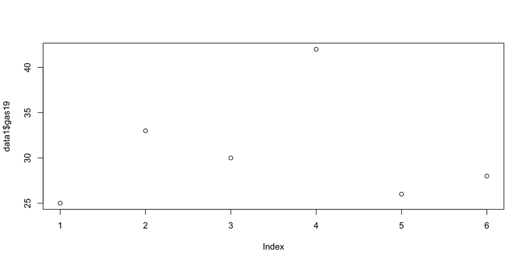

```r
hist (data1$gas19)
```

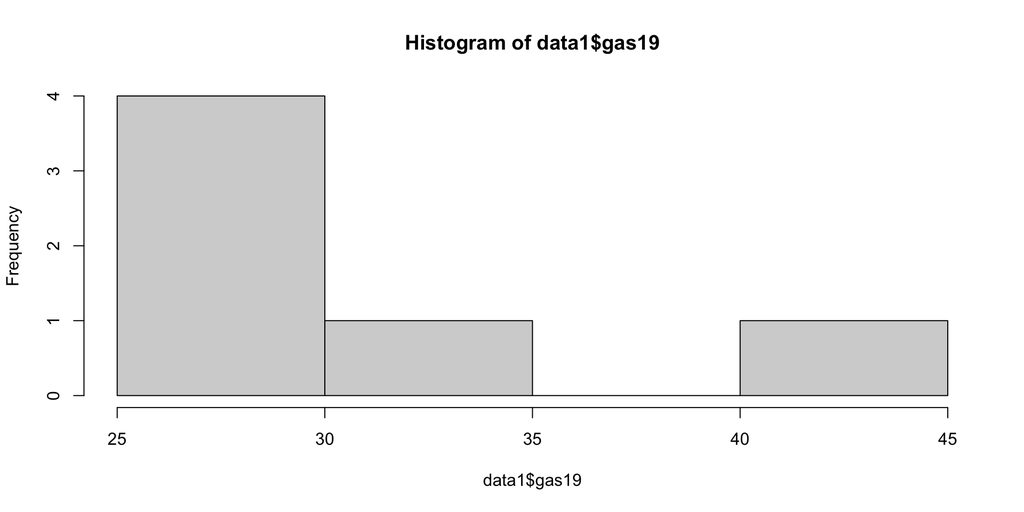

```r
boxplot (data1$gas19)
```

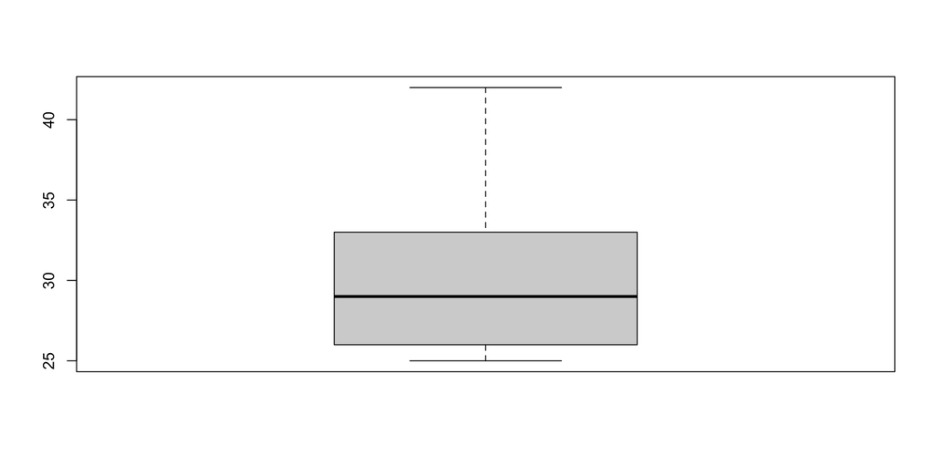

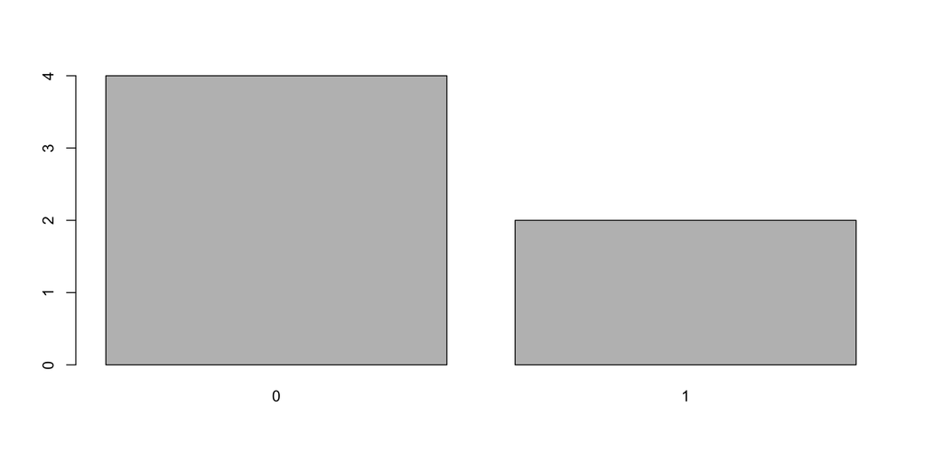

```r
barplot(table (data1$exp19))
```

- Exemplos

```r
example (plot)

example (hist)

example (barplot)

example (boxplot)

example (graph)
```

## Tarefa: Explorar

?plot

Uma forma de explorar: copiar/colar um exemplo:

```r
plot(x <- sort(rnorm(47)), type = "s", main = "plot(x, type = \"s\")")

points(x, cex = .5, col = "dark red")
```

# 12. SIMULAÇÕES

## Distribuição Normal

```r
rnorm (10)   # standard normal dist.(mean=0,st.dev=1), 10 n
```

```
 [1]  0.03988388 -2.08323950  2.21318108  0.45341956  0.45672125 -0.62111711
 [7] -1.23417002  0.53438210  1.91329070  0.06784145
```

```r
rnorm (10, 100, 25) # normal dist.with m=100,std=25)
```

```
 [1]  98.38204  86.70727 110.97990 105.12527 106.24314  92.63467  82.87788
 [8]  86.13318 123.55442 108.45079
```

```r
rnorm (10, 1.60, .10) # altura media mujeres en pais X
```

```
 [1] 1.634014 1.507878 1.583721 1.605921 1.892759 1.547215 1.657855 1.557239
 [9] 1.467874 1.615229
```

```r
hist (rnorm (100, 1.60, .10))
```

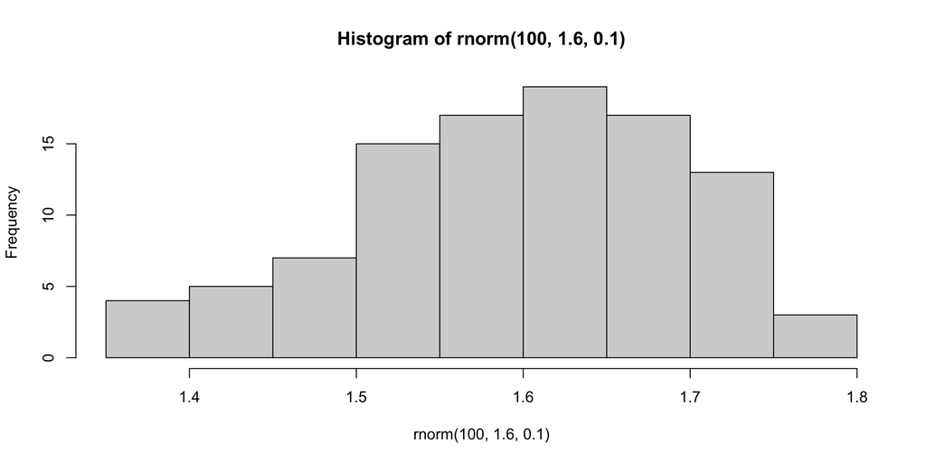

```r
hist (rnorm (100, 1.60, .10))
hist (rnorm (100, 1.60, .10))
hist (rnorm (100, 1.60, .10))
hist (rnorm (100, 1.60, .10))
hist (rnorm (100, 1.60, .10))
hist (rnorm (100, 1.60, .10))
hist (rnorm (100, 1.60, .10))
hist (rnorm (100, 1.60, .10))
hist (rnorm (100, 1.60, .10))
```

## Moeda

```r
sample (0:1, 10, replace=T)
```

```
 [1] 0 0 0 0 0 1 0 1 1 1
```

```r
sample (c(0,1), 100, replace=TRUE)
```

```
  [1] 0 0 0 1 1 1 0 1 0 0 1 1 0 1 0 0 1 1 0 0 0 1 1 1 0 1 0 1 0 0 1 0 0 0 1 1 0
 [38] 1 1 1 0 0 1 0 1 1 1 1 1 0 1 1 1 0 1 1 1 0 1 0 0 1 1 0 1 0 1 0 0 1 1 0 0 0
 [75] 0 0 1 1 0 1 0 1 1 0 1 1 1 1 0 0 0 1 1 1 1 0 1 0 0 0
```

```r
hist (sample (c(0,1), 100, replace=TRUE))
```

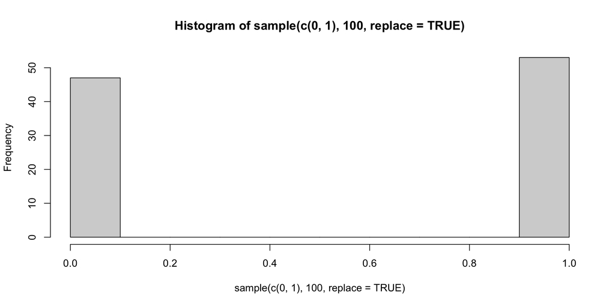

```r
hist (sample (c(0,1), 100, replace=TRUE))
hist (sample (c(0,1), 100, replace=TRUE))
hist (sample (c(0,1), 100, replace=TRUE))
```

. . .

```r
hist( sample (c(0,1), 100, replace=TRUE, prob=c(0.3, 0.7)))
hist( sample (c(0,1), 100, replace=TRUE, prob=c(0.3, 0.7)))
hist( sample (c(0,1), 100, replace=TRUE, prob=c(0.3, 0.7)))
hist( sample (c(0,1), 100, replace=TRUE, prob=c(0.3, 0.7)))
```

## Dado

```r
sample (1:6, 4, replace=TRUE)
```

```
[1] 1 4 1 1
```

```r
sample (1:6, 4, replace=TRUE)
```

```
[1] 6 3 1 6
```

```r
sample (1:6, 4, replace=TRUE)
```

```
[1] 2 1 2 4
```

```r
sample (1:6, 4, replace=TRUE)
```

```
[1] 1 5 2 2
```

```r
moeda <- sample (c(0,1), 100, replace=TRUE, prob=c(0.3, 0.7))


moeda
```

```
  [1] 1 1 1 1 1 1 1 1 0 0 1 1 0 1 0 1 1 1 1 1 1 1 1 1 1 1 1 0 0 1 0 1 0 1 1 1 1
 [38] 1 0 1 0 0 0 0 0 1 0 1 1 1 0 0 0 1 0 1 1 1 0 1 0 1 0 1 1 0 0 0 1 1 1 0 1 0
 [75] 1 1 0 1 1 1 1 0 0 0 0 0 1 1 1 0 1 1 0 0 0 1 1 1 1 0
```